# Fill-in values VS machine readings

To discuss:

- Validate method
- BPA and TRCS outliers
- For compounds between 30% and 50% do we do both categorisation and fill-in and provide sensitivity analyses?

# 1 Intro

This document is the continuation of the document `imputation_below_lod.html` where we discuss the reasons that lead us to choose the fill-in method to impute values below LOD and between LOD and LOQ for compounds with less than 30% data below LOQ.

Compounds with more than 30% samples < LOQ will be categorized as:

- 1: Below LOD
- 2: Between LOD ans LOQ
- 3: Above LOQ

Here we explain the **fill-in** method in some detail, show it’s implementation in R and compare the fill-in values to the machine readings they replace to confirm the relevance of the process.

This analysis is limited to the **pregnancy data**.

# 2 Fill-in method presentation

This method was developed in (Helsel 1990), described in (Lubin et al. 2004) and applied in (Moschandreas 2001):

> “An investigator first characterizes the form of the distribution and estimates its parameters and then assigns randomly sampled values [below LOD and between LOD and LOQ] from the estimated distribution. Fill-in values along with measured values above the [LOQ] are then used in analyses. (…) As described by Helsel (1990) and applied by Moschandreas et al. (2001b), the fill-in method* [does] not include complex modeling of regression factors. In addition, although the fill-in approach* [assigns] random values from an appropriate distribution, it [does] not account for the variability of the imputation process, because the inserted values are not real data.” — (Lubin et al. 2004)

Before parameter estimation we need our data to fit a parametric distribution, hence we start by **box-cox transforming** our data for it to fit a normal distribution.

Hence the different steps of the imputation process are:

1. Apply box-cox transformation
2. Estimate distribution parameters
3. Fill-in values using the distribution parameters

After that will come additional data manipulation steps such as correction on protocol variables and box-cox back transformations which are not the goal of this document.

## 2.1 Box-cox transformation

First we normalise our data using `EnvStats::boxcoxCensored`. This function allows to compute box-cox transformation on data that contains left censorship. It’s the data above LOQ that is used to estimate the closest transformation to normality. For compounds with all values above LOQ, the classic boxcox transformation is applied with `EnvStats::boxcox`.

## 2.2 Parameter estimation

Once data is transformed we compute the left-censored distribution’s mean and standard deviation using `NADA::cenros`, a procedure to robustly compute summary statistics with least-squares regression on a probability plot. This method is called **regression on order statistics - ROS** (Helsel 2012, Chap. 6).

## 2.3 Fill-in

Using the parameters of the distribution computed in the previous step, we replace data below LOD and between LOD and LOQ by random draws from a truncated normal distribution using `msm::rtnorm`. Data are drawn either between box-cox(0) and box-cox(LOD) or between box-cox(LOD) and box-cox(LOQ) depending on the censorship interval.

# 3 Application on Sepages data

Here we apply the fill-in method on sepages compounds with **less than 30% data < LOQ** (see `imputation_below_lod.html` for explanation).

## 3.1 Before fill-in

To visualise the normality of box-cox transformed compounds, check folder `figs/censored_qqplots/`, I had problems combining multiple censored qqplots and didn’t want to lose time on that…

## 3.2 Distributions after fill-in

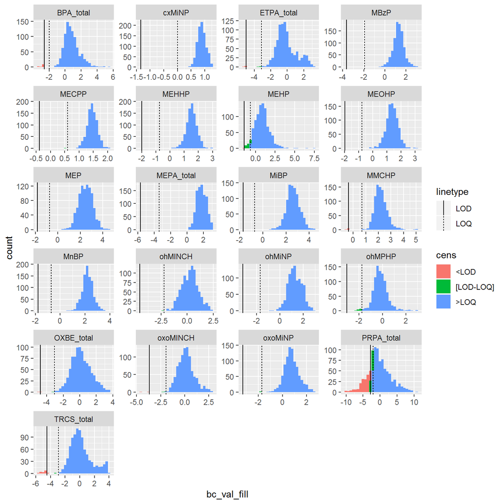

Regarding values below LOD for **BPA** and **TRCS** that clearly seem to be outliers, the reason is most probably an artifact due to the shape of the distribution and the quality of the boxcox transform but **NOT TOO SURE HOW TO INTERPRET, NEEDS DISCUSSION**

Not too sure if it’s a big problem as once back-transformed these values will still be between 0 and LOD which is always a small range. But it might be the sign of an aother issue.

As an illustration, back transformed BPA levels:

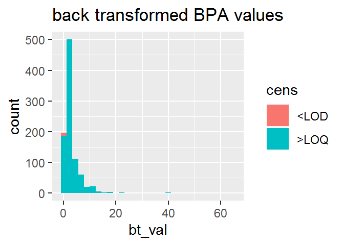

## 3.3 Normal qqplots after fill-in

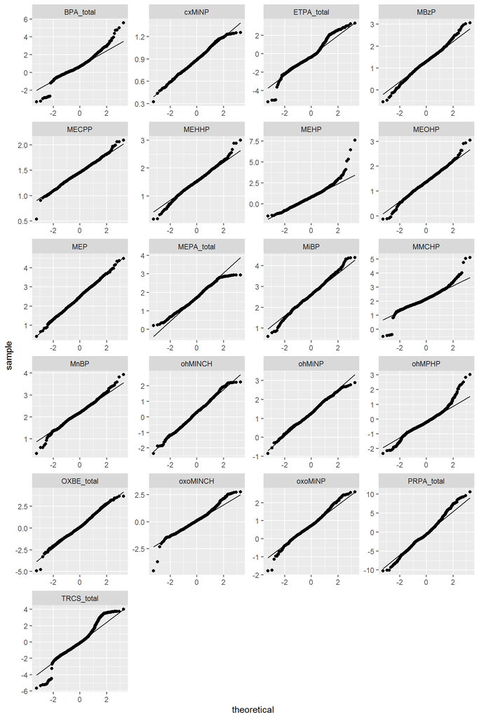

## 3.4 Conclusions

- Fill-in overall works well
- **Discuss outliers**

# 4 Fill-in values VS machine readings

Here we compare the fill-in values and the machine readings. If they follow the same distribution, we might as well use the machine readings.

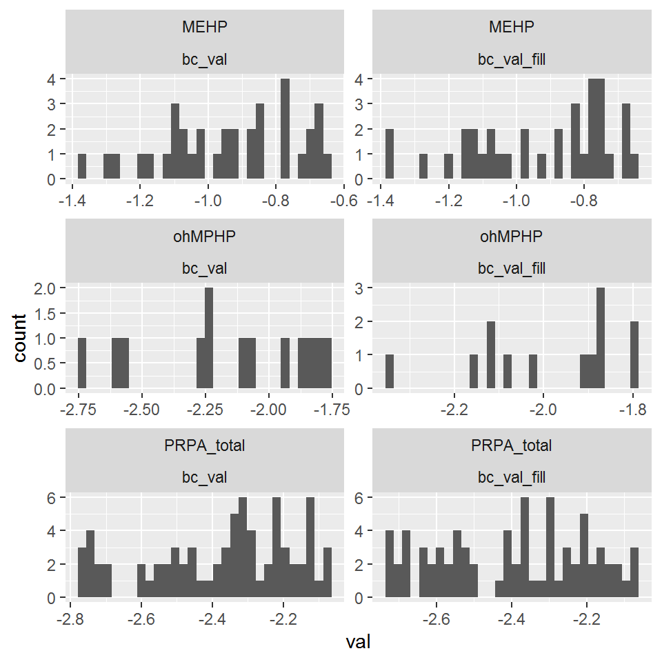

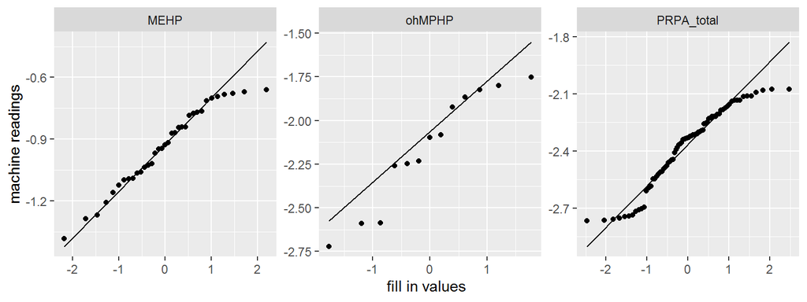

- Distributions differ, as expected more values “to the right” in the fill-ins
- We should use fill-ins and not machine readings

# 5 Overall conclusions

- Fill-in works well (confirm outliers `BPA` and `TRCS`)
- Fill-in values to be preferred over machine readings

# References

Helsel, Dennis R. 1990. “Less Than Obvious - Statistical Treatment of Data Below the Detection Limit.” *Environmental Science & Technology* 24 (12): 1766–74. https://doi.org/10.1021/es00082a001.

———. 2012. *Statistics for Censored Environmental Data Using Minitab® and R*. 2. ed. Statistics in Practice. Hoboken, NJ: Wiley.

Lubin, Jay H., Joanne S. Colt, David Camann, Scott Davis, James R. Cerhan, Richard K. Severson, Leslie Bernstein, and Patricia Hartge. 2004. “Epidemiologic Evaluation of Measurement Data in the Presence of Detection Limits.” *Environmental Health Perspectives* 112 (17): 1691–6. https://doi.org/10.1289/ehp.7199.

Moschandreas, D. 2001. “In-Residence, Multiple Route Exposures to Chlorpyrifos and Diazinon Estimated by Indirect Method Models.” *Atmospheric Environment* 35 (12): 2201–13. https://doi.org/10.1016/S1352-2310(00)00474-X.

Matthieu Rolland

05/11/2019